# Youtube Trending Videos

## Part 1: Background

Often times, when I’m browsing on Youtube, I’m always wondering why those videos can jump to the trending list. There is a pretty handy and complex algorithm behind the scene.

However, for this analysis, I will focus on using statistical methods to solve three problems:

- Should YouTubers publish their videos on weekend or weekdays?
- Whether getting into trending required same amount of views among different groups? or are they different?
- Is there a relationship between views and number of tags when a video goes on trending?

### 1. Load the data and import packages

```r
library(tidyverse)
library(lubridate)
youtube_orig <- read.csv("/Volumes/GoogleDrive/Shared drives/Statistics Final Presentation/youtube/youtube1.csv")
youtube <- youtube_orig
```

### 2. Data Overview

```r
rmarkdown::paged_table(head(youtube))
```

|  | video_id | trending_date | title | channel_title | category_id | publish_time | tags | views | likes | dislikes | comment_count | thumbnail_link | comments_disabled | ratings_disabled | video_error_or_removed | description |
| --- | --- | --- | --- | --- | --- | --- | --- | --- | --- | --- | --- | --- | --- | --- | --- | --- |
| 1 | 1A_aWbz6D5A | 18.04.02 | The BIGGEST Moments From the 2018 Grammys: Kesha, Bruno Mars, Kendrick Lamar, & Hillary Clinton | Entertainment Tonight | 24 | 2018-01-29T05:04:08.000Z | grammys 2018 performances\|grammys 2018\|Grammys 2018\|grammy awards\|grammys hillary clinton\|bruno mars\|Entertainment Tonight\|etonline\|et online\|celebrity\|hollywood\|news\|trending\|et\|et toni… | 412054 | 1655 | 1933 | 615 | https://i.ytimg.com/vi/1A_aWbz6D5A/default.jpg | False | False | False | More from Entertainment Tonight: https://www.youtube.com/channel/UCdtXPiqI2cLorKaPrfpKc4g?sub_confirmation=1\\nET's Denny Directo, Sophie Schillaci, and Lauren Zima bring you the BIGGEST moments from … |
| 2 | 9oyKePWRi8Y | 17.29.12 | Best of 2017 \| Dude Perfect | Dude Perfect | 17 | 2017-12-26T22:55:15.000Z | dude perfect\|dude perfect stereotypes\|dude perfect water bottle flip\|bottle flip\|water bottle flip\|dude perfect bottle flip\|dude perfect basketball\|dp\|dude perfect world record\|edition\|nerf\… | 6969112 | 324853 | 3151 | 16270 | https://i.ytimg.com/vi/9oyKePWRi8Y/default.jpg | False | False | False | It's time for our BEST and FUNNIEST moments from 2017!\\n► Click HERE to subscribe to Dude Perfect! http://bit.ly/SubDudePerfect\\n► Click HERE to watch all our videos from this year! http://bit.ly/Be… |
| 3 | YpUDblEURdY | 18.31.05 | We Tried To Make The Most Intimidating Pasta Dish (Timpano) | Tasty | 26 | 2018-05-26T15:00:09.000Z | BuzzFeed\|BuzzFeed Tasty\|Tasty\|pasta\|timpano\|eating your feed\|how to cook pasta\|eggs\|sausage\|lasagna\|marinara | 2217132 | 55923 | 2308 | 3387 | https://i.ytimg.com/vi/YpUDblEURdY/default.jpg | False | False | False | “A little danger adds a lot of excitement to a meal!” Check us out on Facebook! - facebook.com/buzzfeedtastyCredits: https://www.buzzfeed.com/bfmp/videos/52963MUSICSFX Provided By AudioBlocks(https://… |
| 4 | -sXnoM6rDB4 | 18.10.02 | I GOT FIRED... | Jack Coyne | 22 | 2018-02-05T22:51:37.000Z | Casey neistat\|beme\|jack coyne\|beme news\|start up\|cnn\|cnn beme\|jake roper\|lou\|vsauce3\|lou foglia\|casey\|casey and jack | 738118 | 30875 | 881 | 2327 | https://i.ytimg.com/vi/-sXnoM6rDB4/default.jpg | False | False | False | The story of how I worked with Casey Neistat for the last 8 years, and what I'm up to next. \\n\\nMuch love to the Beme family\\n\\nFollow me on...\\nTwitter: twitter.com/jackycoyne\\nInstagram: insta… |
| 5 | ve3oQBjcAGI | 17.16.11 | Everything Wrong With Wonder Woman In 14 Minutes Or Less | CinemaSins | 1 | 2017-11-14T17:00:07.000Z | wonder woman\|gal gadot\|everything wrong with\|eww\|cinemasins\|cinema sins\|movie\|mistakes\|review | 1496471 | 43974 | 2045 | 9442 | https://i.ytimg.com/vi/ve3oQBjcAGI/default.jpg | False | False | False | Wonder Woman was one of 2017's best summer movies. There... I said it. (pause). Now onto its sins...\\n\\nThursday: A 2017 movie nowhere near as good as Wonder Woman.\\n\\nRemember, no movie is withou… |
| 6 | cr6H8ACWp4E | 18.16.03 | The Cast of ‘All That’ Is Here & No One Can Handle It \| Wild 'N Out \| MTV | MTV | 24 | 2018-03-15T11:00:02.000Z | mtv\|video\|online\|official\|tv\|television\|watch\|freestyle\|comedy\|improv\|comedians\|battle\|Anthony\|Chico\|Conceited\|DC Young Fly\|DJ D-Wrek\|Darren Brand\|DeRay Davis\|Hitman Holla\|Karlous … | 177839 | 5791 | 60 | 391 | https://i.ytimg.com/vi/cr6H8ACWp4E/default.jpg | False | False | False | All your favorites from ‘All That’ stop by this week for an hour long special edition of Wild ‘N Out!\\n\\n#MTV #WildNOut #WNO #AllThat\\n\\nSubscribe to MTV: http://goo.gl/NThuhC\\n\\nWild 'N Out is … |

There are **16** variables in total:

- Numerical Variables: : views, likes, dislikes, comment_count
- Categorical Variables: channel_title, category_id, tags, comments_disabled, ratings_disabled, video_error_or_removed
- Time Variables: trending_date, publish_time
- Others: video_id, title, thumbnail_link, description

Each video may be put on the trending list more than once.

### 3. Data Processing

Since each video can show up several times in this dataset, lots of repetitive information exists.

Moreover, all the numeric variables are cumulative, which means certain data processing methods are needed for the growth analysis concerning these variables.

I will select the first trending data for each video in order to avoid time-series influence

```r
youtube_first_trending <- youtube %>%
  group_by(video_id) %>%
  mutate(first_trending = min(ydm(trending_date))) %>%
  filter(ydm(trending_date) == first_trending) %>%
  separate(publish_time, c("date","time"), sep="T") %>%
  filter(date>="2017-12-01") %>%
  dplyr::select(video_id, trending_date, date, time,title, channel_title,
                category_id, views,likes, dislikes, comment_count,tags) %>%
  distinct()
```

## Part 2: Two-sample T-Test

### 1. Video Views on Weekends vs. Weekdays

Now, we will start our statistical analysis on the youtube trending video datasets.

As a YouTuber, you will probably wonder if you should publish your videos during the weekends and weekdays to get more views. I have the intuition that people will tend to watch YouTube videos on weekends more than on weekdays.

Here comes our hypothesis:

- H0: Trending videos have the same number of views on weekends and weekdays.
- H1: Trending videos have different numbers of views ib weekebds and weekdays.

```r
youtube_ttest <- youtube_first_trending %>%
  mutate(week_day = weekdays(ymd(date))) %>%
  mutate(weekend=ifelse((week_day=="Saturday" | week_day=="Sunday"),1,0))

t.test(youtube_ttest$views ~ youtube_ttest$weekend,
       alternative = "two.sided", var.equal = TRUE)
```

```
    Two Sample t-test

data:  youtube_ttest$views by youtube_ttest$weekend
t = -0.57401, df = 5122, p-value = 0.566
alternative hypothesis: true difference in means is not equal to 0
95 percent confidence interval:
 -207958.3  113759.9
sample estimates:
mean in group 0 mean in group 1
       903171.8        950271.0
```

### 2. Findings

Based on the t-test output, we can see we have a p-value of 0.566, which is far larger than 0.05, the pre-decided significance level.

Therefore, the H0 cannot be rejected, and trending videos tend to have the same number of views during weekday and weekend.

This gives us the information that there is no difference in terms of views whether you decide to publish videos on weekdays and weekends.

## Part 3: ANOVA Test

### 1. Video Views and Category ID

```r
length(unique(youtube$category_id))
```

```
[1] 16
```

There are 16 video categories in our dataset. I’m curious about if there is a significant difference in views among different video categoris. Whether getting into Trending required same amount of views among different groups? or are they different?

- H0: Trending videos have the same number of views across different categories.
- H1: Trending videos have different numberd of views across different categories.

I did an ANOVA test here to compare the means of views when videos go on trending first time for each category.

```r
categoryTest <- aov(data = youtube_first_trending, views~as.factor(category_id))
summary(categoryTest)
```

```
                         Df    Sum Sq   Mean Sq F value Pr(>F)
as.factor(category_id)   15 9.143e+14 6.096e+13   12.46 <2e-16 ***
Residuals              5108 2.498e+16 4.891e+12
---
Signif. codes:  0 '***' 0.001 '**' 0.01 '*' 0.05 '.' 0.1 ' ' 1
```

```r
TukeyHSD(categoryTest)
```

```
  Tukey multiple comparisons of means
    95% family-wise confidence level

Fit: aov(formula = views ~ as.factor(category_id), data = youtube_first_trending)

$`as.factor(category_id)`
               diff         lwr          upr     p adj
2-1    -740489.9144 -1911876.50   430896.670 0.7206363
10-1    543012.9762   -18102.04  1104127.988 0.0704164
15-1   -925429.9848 -1772885.08   -77974.887 0.0170821
17-1   -243312.2550  -861688.61   375064.103 0.9940309
19-1   -994647.9144 -2166034.50   176738.670 0.2098810
20-1    157764.5890  -759135.41  1074664.591 0.9999998
22-1   -396590.4703  -999304.29   206123.354 0.6570303
23-1   -396911.2513  -990858.36   197035.861 0.6308456
24-1   -309496.4242  -825882.55   206889.701 0.7939473
25-1   -946659.0337 -1550523.04  -342795.030 0.0000095
26-1   -715678.8993 -1299424.40  -131933.399 0.0028207
27-1   -865376.8991 -1572754.32  -157999.478 0.0029305
28-1   -598233.5771 -1242906.09    46438.936 0.1046535
29-1    126253.8256 -2112473.24  2364980.886 1.0000000
43-1   -857047.1744 -4676758.48  2962664.129 0.9999935
10-2   1283502.8906   169279.18  2397726.596 0.0078920
15-2   -184940.0703 -1467447.21  1097567.065 1.0000000
17-2    497177.6594  -646952.46  1641307.779 0.9838366
19-2   -254158.0000 -1770334.42  1262018.421 0.9999999
20-2    898254.5034  -431162.67  2227671.678 0.6116742
22-2    343899.4442  -791841.88  1479640.772 0.9996961
23-2    343578.6631  -787534.76  1474692.089 0.9996842
24-2    430993.4902  -661388.79  1523375.768 0.9938585
25-2   -206169.1193 -1342521.24   930183.003 0.9999996
26-2     24811.0152 -1100979.03  1150601.057 1.0000000
27-2   -124886.9846 -1319469.43  1069695.464 1.0000000
28-2    142256.3373 -1016297.53  1300810.203 1.0000000
29-2    866743.7400 -1570168.91  3303656.390 0.9980010
43-2   -116557.2600 -4055699.15  3822584.632 1.0000000
15-10 -1468442.9610 -2234946.76  -701939.159 0.0000000
17-10  -786325.2312 -1288059.48  -284590.983 0.0000096
19-10 -1537660.8906 -2651884.60  -423437.185 0.0002604
20-10  -385248.3872 -1227895.14   457398.366 0.9740014
```

[output cut: 72 more lines]

```
26-25   230980.1344  -278832.01   740792.280 0.9760695
27-25    81282.1346  -566431.10   728995.367 1.0000000
28-25   348425.4566  -230152.34   927003.251 0.7879575
29-25  1072912.8593 -1147683.56  3293509.281 0.9576328
43-25    89611.8593 -3719501.43  3898725.149 1.0000000
27-26  -149697.9998  -778696.81   479300.811 0.9999858
28-26   117445.3222  -440102.29   674992.932 0.9999972
29-26   841932.7248 -1373277.32  3057142.769 0.9958635
43-26  -141368.2752 -3947343.99  3664607.438 1.0000000
28-27   267143.3220  -418774.56   953061.207 0.9946377
29-27   991630.7246 -1259320.09  3242581.535 0.9815825
43-27     8329.7246 -3818558.72  3835218.165 1.0000000
29-28   724487.4027 -1507551.88  2956526.690 0.9993015
43-28  -258813.5973 -4074609.05  3556981.859 1.0000000
43-29  -983301.0000 -5360125.32  3393523.325 0.9999934
```

### 2. Findings

The result of the ANOVA test shows a p-value that is greatly smaller than 0.05, the pre-decided significance level.

Therefore, the H0 should be rejected, and trending videos tend to have different numbers of views across different categories.

## Part 4: Regression Model

### 1. Relationship between video views and number of tags

YouTube videos usually have a lot of tags. The tags are separate by the “|”. Let’s see two examples below:

```r
head(youtube$tags,2)
```

```
[1] grammys 2018 performances|grammys 2018|Grammys 2018|grammy awards|grammys hillary clinton|bruno mars|Entertainment Tonight|etonline|et online|celebrity|hollywood|news|trending|et|et tonight|cbs|nominee|producer|album of the year|red carpet|highlights|recording academy|performances|interviews|kes…
[2] dude perfect|dude perfect stereotypes|dude perfect water bottle flip|bottle flip|water bottle flip|dude perfect bottle flip|dude perfect basketball|dp|dude perfect world record|edition|nerf|trick shots|trick shot|family|ping pong|bowling|clean|family friendly|bubble wrap|soccer|football|spinner|…
5839 Levels: “Developer Update | Year of the Dog | Overwatch|” Overwatch Developer Update Year of the Dog|Overwatch Developer Update Lunar New Year|Overwatch Capture the Flag|Competitive Capture the Flag|Lunar New Year|Blizzard Entertainment|Blizzard|FPS|First-Person Shooter|Team-Based Shooter|Objec…
```

Is there a relationship between views and number of tags when a video goes on trending?

In theory, the more tags a video has, the more likely it will show up in searches, and more people will watch it.

Our hypothesis: *number of tags has a positive relationship with views for videos first on trending*

Let’s run a simple linear regression to test our findings:

$$Views\ = \beta_0\ + \beta_1\ * Num\ of\ Tags$$
$$H_0: \beta_1\ = 0$$
$$H_1: \beta_1\ != 0$$

```r
youtube_tags <- youtube_first_trending %>%
  mutate(tags = as.character(tags)) %>%
  mutate(numTags = ifelse((tags == "[none]"),
                          0, str_count(tags, "\\|")+1))

model_tags <- lm(data = youtube_tags, views~numTags)
summary(model_tags)
```

```
Call:
lm(formula = views ~ numTags, data = youtube_tags)

Residuals:
     Min       1Q   Median       3Q      Max
-1209746  -778166  -581419   -27130 47494901

Coefficients:
            Estimate Std. Error t value Pr(>|t|)
(Intercept)   779531      60668  12.849   <2e-16 ***
numTags         6551       2576   2.544    0.011 *
---
Signif. codes:  0 '***' 0.001 '**' 0.01 '*' 0.05 '.' 0.1 ' ' 1

Residual standard error: 2247000 on 5122 degrees of freedom
Multiple R-squared:  0.001261,  Adjusted R-squared:  0.001066
F-statistic: 6.469 on 1 and 5122 DF,  p-value: 0.011
```

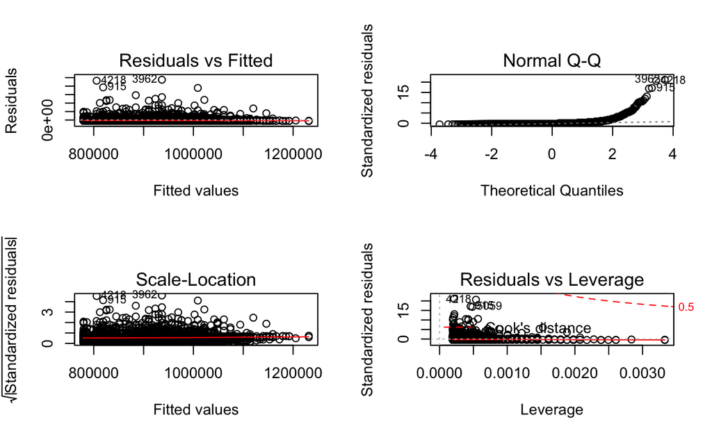

```r
par(mfrow = c(2, 2))
plot(model_tags)
```

### 2. Findings

The coefficient has a 0.011 p-value that is smaller than 0.05, the pre-decided significance level. Thus, the H0 should be rejected, and the number of tags for a video can positively influence its number of views.

However, the following diagnostic plots show that the residuals are not normally distributed, and the r-square is only 0.001261. The F-statistic is 6.469, which also means this model is not a good fit to the dataset.

## Part 5: Revised Regression Model

### 1. Use music and news&politics categories as dummy variables

Can we improve our model? According to the ANOVA test in part 3, we know that category 10 (music) and category 25 (news & politics)’s views usually different from others. So I want to use *Music* and *News&Politics* as dummy variables and add to our linear model.

$$Views\ = \beta_0\ + \beta_1\ * Num\ of\ Tags\ + \beta_2\ * Dummy_{music}\ +\beta_3\ *\ Dummy_{news}$$
$$H_0: \beta_1\ = 0,\ \beta_2\ = 0,\ \beta_3\ = 0$$
$$H_1: \beta_1\ != 0,\ \beta_2\ != 0,\ \beta_3\ != 0$$

```r
youtube_dummy <- youtube_tags %>%
  mutate(music = ifelse(category_id == 10, TRUE, FALSE)) %>%
  mutate(news = ifelse(category_id == 25, TRUE, FALSE))

model <- lm(data = youtube_dummy, views~numTags+music+news)
summary(model)
```

```
Call:
lm(formula = views ~ numTags + music + news, data = youtube_dummy)

Residuals:
     Min       1Q   Median       3Q      Max
-2054061  -711033  -471077    41170 46522836

Coefficients:
            Estimate Std. Error t value Pr(>|t|)
(Intercept)   602220      66246   9.091  < 2e-16 ***
numTags        10827       2615   4.141 3.52e-05 ***
musicTRUE    1046748      97401  10.747  < 2e-16 ***
newsTRUE     -459943     116592  -3.945 8.09e-05 ***
---
Signif. codes:  0 '***' 0.001 '**' 0.01 '*' 0.05 '.' 0.1 ' ' 1

Residual standard error: 2216000 on 5120 degrees of freedom
Multiple R-squared:  0.02879,   Adjusted R-squared:  0.02822
F-statistic: 50.59 on 3 and 5120 DF,  p-value: < 2.2e-16
```

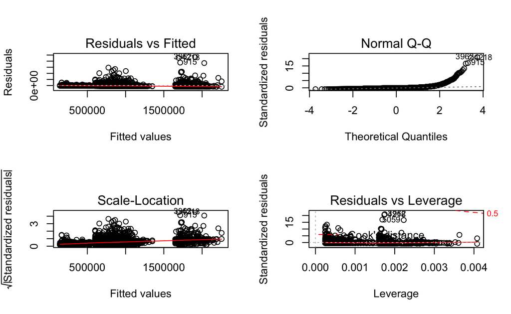

```r
par(mfrow = c(2, 2))
plot(model)
```

### 2. Findings

All three coefficients have p-values that are smaller than 0.05, the pre-decided significance level. Thus, the H0 should be rejected, and the number of tags and the music dummy has a positive impact on video views, while the news dummy has a negative one.

## Part 6: Limitations

1. This dataset doesn’t include data of those videos falling out of the trending list, which can be utilized to determine the views threshold of the trending list.
2. This analysis assumes the trending list is daily updated, while it actually may be updated every 15 minutes. This proxy leads to inaccuracy.
3. The revised model still doesn’t have a high r-square and F-statistic, which means further analysis is needed to explore the relationship.